# **Malaria Detection - Final Submission**

## Context

Malaria is a contagious disease caused by **Plasmodium parasites** that are transmitted to humans through the bites of infected female Anopheles mosquitoes. The parasites enter the blood and begin damaging red blood cells (RBCs) that carry oxygen, which can result in respiratory distress and other complications. The lethal parasites can stay alive for more than a year in a person’s body without showing any symptoms. Therefore, late treatment can cause complications and could even be fatal. Almost 50% of the world’s population is in danger from malaria. There were more than 229 million malaria cases and 400,000 malaria-related deaths reported over the world in 2019. Children under 5 years of age are the most vulnerable population group affected by malaria; in 2019 they accounted for 67% of all malaria deaths worldwide.

Traditional diagnosis of malaria in the laboratory requires careful inspection by an experienced professional to discriminate between healthy and infected red blood cells. It is a tedious, time-consuming process, and the diagnostic accuracy (which heavily depends on human expertise) can be adversely impacted by inter-observer variability.

An automated system can help with the early and accurate detection of malaria. Applications of automated classification techniques using Machine Learning (ML) and Artificial Intelligence (AI) have consistently shown higher accuracy than manual classification. It would therefore be highly beneficial to propose a method that performs malaria detection using Deep Learning Algorithms.

## Looking at the Numbers

If we examine the numbers from the **World Health Organization** we can get a sense of the scope of the problem.

```python
# Reading in the data
mal_cases = pd.read_csv("malaria_data.csv")
```

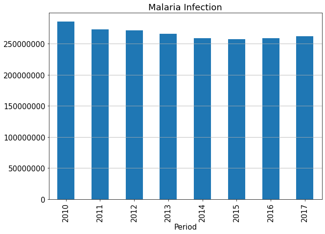

```python
# Plotting Malaria Cases per Year
plt.rc('font', size=15)
plt.figure(figsize=(10, 7))
plt.title('Malaria Infection')
plt.ticklabel_format(style='plain')
ax = mal_cases[mal_cases.SpatialDimValueCode == 'GLOBAL'].groupby(mal_cases.Period).FactValueNumericHigh.sum().plot.bar(grid=True)
ax.grid(axis='x')
plt.show()
```

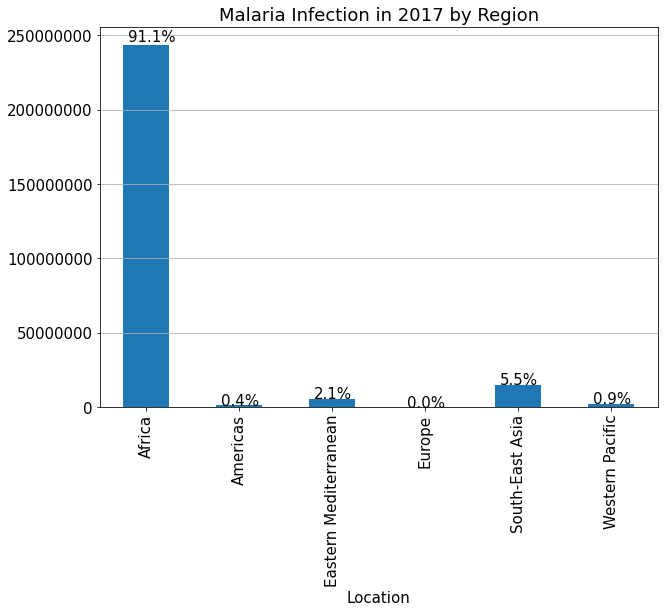

```python
mal_cases_2017 = mal_cases[mal_cases.Period == 2017]


# Plotting Malaria Cases per Region in 2017
plt.rc('font', size=15)
plt.figure(figsize=(10, 7))
plt.title('Malaria Infection in 2017 by Region')
plt.ticklabel_format(style='plain')
ax = mal_cases_2017[mal_cases_2017.Location != '(WHO) Global'].groupby('Location').FactValueNumericHigh.sum().plot.bar(grid=True)
ax.grid(axis='x')


total = mal_cases_2017[mal_cases_2017.Location != '(WHO) Global'].FactValueNumericHigh.sum()
for p in ax.patches:
        percentage = '{:.1f}%'.format(100 * p.get_height()/total)
        x = p.get_x() + p.get_width() / 9
        y = p.get_y() + p.get_height() * 1.01
        ax.annotate(percentage, (x, y))

plt.show()
```

## The Issue

As we can see, there has consistently been over **250 million** cases of Malaria every year. Over **90%** is in the **African region**. As noted above, 2019 reported **229 million** malaria cases and **400,000** malaria-related deaths reported over the world.

## Advantages

- Alleviates huge cost and labor burden.
- Frees up time and mental power to creatively tackle the issues.
- Saves lives.

## Objective

Build an efficient computer vision model to detect malaria. The model should identify whether the image of a red blood cell is that of one infected with malaria or not, and classify the same as parasitized or uninfected, respectively.

## About the dataset

There are a total of 24,958 train and 2,600 test images (colored) with an equal number of parasitized and uninfected instances, where:

- The parasitized cells contain the Plasmodium parasite
- The uninfected cells are free of the Plasmodium parasites but could contain other impurities

```python
# Matrix and dataframe manipulation
import numpy as np
import pandas as pd
from random import random

# Image operations and plotting
from PIL import Image
from skimage.io import imread, imshow
import matplotlib.pyplot as plt
import seaborn as sns

# File, path and directory operations
import os
import os.path
import pickle
# import shutil
# from glob import glob

# scikit-learn
from sklearn.model_selection import train_test_split
from sklearn.preprocessing import MinMaxScaler
from sklearn.metrics import classification_report
from sklearn.metrics import confusion_matrix

# tensorflow
import tensorflow as tf
from tensorflow import keras
from tensorflow.keras.models import Sequential
from tensorflow.keras.layers import Dense, Conv2D, MaxPool2D, BatchNormalization, Dropout, Flatten, LeakyReLU
from tensorflow.keras.utils import to_categorical
from tensorflow.keras import losses
from tensorflow.keras import optimizers

# For reproducability
np.random.seed(42)
tf.random.set_seed(42)

import time
```

```python
#!pip install keras_tuner
```

```python
# checking current version of tensorflow
print(tf.__version__)
```

```
2.5.0
```

## **Prepping the dataset**

- The original dataset is available as **.png files** organized in folders.
- Since the data is already split into train and the test dataset in respective folders and further split into parasited and uninfected folders. We will need to import from our folders and prep.
- We will convert all images to the **same size** *and* to **4D arrays** so that they can be used as an input for the convolutional neural network. Then we will need to create the labels for both types of images to be able to train and test the model.

```python
# Let's locate where the files are
os.getcwd()
```

```
'C:\\Users\\kre8t\\Documents\\The-Lab\\MIT ADSP 2021\\Capstone Project'
```

### Prepping the training data

```python
#Storing the path of the extracted "train" folder
train_dir = 'cell_images_64/train'

#Size of image so that each image has the same size
SIZE = 64

#Empty list to store the training images after they are converted to NumPy arrays
train_images = []

#Empty list to store the training labels (0 - uninfected, 1 - parasitized)
train_labels = []
```

```python
#We will run the same code for "parasitized" as well as "uninfected" folders within the "train" folder
for folder_name in ['/parasitized/', '/uninfected/']:

    #Path of the folder
    images_path = os.listdir(train_dir + folder_name)

    for i, image_name in enumerate(images_path):
        try:
            #Opening each image using the path of that image
            image = Image.open(train_dir + folder_name + image_name)

            #Resizing each image to (64,64)
            image = image.resize((SIZE, SIZE))

            #Converting images to arrays and appending that array to the empty list defined above
            train_images.append(np.array(image))

            #Creating labels for parasitized and uninfected images
            if folder_name=='/parasitized/':
                train_labels.append(1)
            else:
                train_labels.append(0)
        except Exception:
            pass

#Converting lists to arrays
train_images = np.array(train_images)
train_labels = np.array(train_labels)
```

### Prepping the test data

```python
#Storing the path of the extracted "test" folder
test_dir = 'cell_images_64/test'

#Size of image so that each image has the same size (it must be same as the train image size)
SIZE = 64

#Empty list to store the testing images after they are converted to NumPy arrays
test_images = []

#Empty list to store the testing labels (0 - uninfected, 1 - parasitized)
test_labels = []
```

```python
#We will run the same code for "parasitized" as well as "uninfected" folders within the "test" folder
for folder_name in ['/parasitized/', '/uninfected/']:

    #Path of the folder
    images_path = os.listdir(test_dir + folder_name)

    for i, image_name in enumerate(images_path):
        try:
            #Opening each image using the path of that image
            image = Image.open(test_dir + folder_name + image_name)

            #Resizing each image to (224,224)
            image = image.resize((SIZE, SIZE))

            #Converting images to arrays and appending that array to the empty list defined above
            test_images.append(np.array(image))

            #Creating labels for parasitized and uninfected images
            if folder_name=='/parasitized/':
                test_labels.append(1)
            else:
                test_labels.append(0)
        except Exception:
            pass

#Converting lists to arrays
test_images = np.array(test_images)
test_labels = np.array(test_labels)
```

### Initial exploratory data analysis

```python
# Let's find out how many training and text images
len(train_images), len(test_images)
```

```
(24958, 2600)
```

- There are 24,958 images in the training data and 2,600 images in the testing data.

### Print out some of the images and look at the associated labels

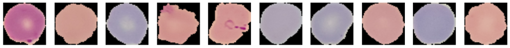

```
label for each of the above image: [1 0 0 0 1 0 0 0 0 0]
```

```python
# visualizing the random 10 images in the dataset and their labels

# select a random sample without replacement
from random import seed
from random import sample

# prepare a sequence
sequence = [i for i in range(len(train_images))]

# select a subset without replacement
subset = sample(sequence, 10)

plt.figure(figsize=(20, 2))

for i in range(10):

    plt.subplot(1, 10, i+1)
    plt.imshow(train_images[subset[i]]) # write the function to visualize images
    plt.axis('off')

plt.show()
print('label for each of the above image: %s' % (train_labels[subset]))
```

- We print out a random set of images and compared with the labels and they correspond.
- Next we will take a look at the dataset and check the shape - it should be 4D arrays and should not need to be further reshaped.
- Next we normalize the train and the test dataset by dividing by 255
- Print the new shapes of the train and the test set

```python
# Normalize inputs from 0-255 to 0-1
train_images_n = train_images / 255.0
test_images_n = test_images / 255.0
```

```python
# Checking the shape of the dataset
print('Training set:', train_images_n.shape, train_labels.shape)
print('Test set:', test_images_n.shape, test_labels.shape)
```

```
Training set: (24958, 64, 64, 3) (24958,)
Test set: (2600, 64, 64, 3) (2600,)
```

```python
train_pos = np.sum(train_labels == 1)
train_neg = np.sum(train_labels == 0)
test_pos = np.sum(test_labels == 1)
test_neg = np.sum(test_labels == 0)
```

```python
print("Positive cases in the training set : ", train_pos)
print("Negative cases in the training set : ", train_neg)
print("Positive cases in the test set : ", test_pos)
print("Negative cases in the test set : ", test_neg)
```

```
Positive cases in the training set :  12479
Negative cases in the training set :  12479
Positive cases in the test set :  1300
Negative cases in the test set :  1300
```

```python
train_images_n.shape
```

```
(24958, 64, 64, 3)
```

## **Proposed Approach**

- **POTENTIAL TECHNIQUES** An automated system can help with the early and accurate detection of malaria. Applications of automated classification techniques using Machine Learning (ML) and Artificial Intelligence (AI) have consistently shown higher accuracy than manual classification. It would therefore be highly beneficial to propose a method that performs malaria detection using Deep Learning Algorithms.
- **OVERALL SOLUTION DESIGN** We will be using building a convolution neural network (CNN) model to classify between infected and non-infected blood cell samples from the images. This is a binary classification problem so we will be using a sigmoid activation function. Our process will be **Data Preparation-> Exploratory Data analysis-> Model Building-> Model evaluation-> Model selection-> Summary of potential benefits-> Recommendation for implementation.**
- **MEASURES OF SUCCESS** We will attempt various models and test accuracy with a loss score. We will also use a 20% validation split for each model to see if training and validation accuracy improve together to determine if the model is overfitting.

```python
test_images_n.shape
```

```
(2600, 64, 64, 3)
```

## **Model Building Continuation**

We built a pretty accurate CNN model in Milestone 2, here we want to do some **hyperparameter tuning** to improve our model and see if we can apply **transfer learning**.

# **Hyperparameter Tuning**

We will do some hyperparameter tuning to get the best model. This process can be time consuming on the front end but it allows us to provide an exhaustive substitution of the hyperparameters to get the best model.

### **Defining our hypermodel**

```python
def build_model(hp):  # random search passes this hyperparameter() object
    model = keras.models.Sequential()

    model.add(Conv2D(hp.Int('input_units',
                                min_value=16,
                                max_value=160,
                                step=16), (3, 3), padding="same", input_shape=train_images_n.shape[1:]))
    model.add(LeakyReLU(alpha=0.1))
    model.add(Dropout(hp.Float('dropout',
                    min_value=0.0,
                    max_value=0.9,
                    step=0.1)))

    for i in range(hp.Int('n_layers', 1, 4)):  # adding variation of layers.
        model.add(Conv2D(hp.Int(f'conv_{i}_units',
                                min_value=32,
                                max_value=256,
                                step=32), (3, 3), padding="same",))
        model.add(LeakyReLU(alpha=0.1))
        model.add(MaxPool2D(pool_size=(2, 2)))
        model.add(Dropout(hp.Float('dropout',
                    min_value=0.0,
                    max_value=0.9,
                    step=0.1)))

    model.add(Flatten())

    model.add(Dense(hp.Int('input_units',
                                min_value=16,
                                max_value=160,
                                step=16)))
    model.add(LeakyReLU(alpha=0.1))
    model.add(Dropout(hp.Float('dropout',
                    min_value=0.0,
                    max_value=0.9,
                    step=0.1)))
    model.add(Dense(1, activation='sigmoid'))

    adam = optimizers.Adam(
        learning_rate=tf.Variable(0.001),
        beta_1=tf.Variable(0.9),
        beta_2=tf.Variable(0.999),
        epsilon=tf.Variable(1e-7))
    adam.iterations
    adam.decay = tf.Variable(0.0)

    model.compile(
        loss = 'binary_crossentropy',
        optimizer = adam,
        metrics = ['accuracy'])

    return model
```

### **Random Search**

The Random Search hyperparameter tuning method randomly tries a combination of hyperparameters from a given search space.

```python
from keras_tuner import HyperModel, RandomSearch, Hyperband, BayesianOptimization

LOG_DIR = f"{int(time.time())}"

tuner = RandomSearch(
    build_model,
    objective='val_accuracy',
    max_trials=1,  # how many model variations to test?
    executions_per_trial=1,  # how many trials per variation? (same model could perform differently)
    directory=LOG_DIR)

tuner.search(x=train_images_n,
             y=train_labels,
             verbose=2, # just slapping this here bc jupyter notebook. The console out was getting messy.
             epochs=2,
             batch_size=64,
             validation_data=(test_images_n, test_labels))
```

```
Trial 1 Complete [00h 23m 31s]
val_accuracy: 0.9530768990516663

Best val_accuracy So Far: 0.9530768990516663
Total elapsed time: 00h 23m 31s
INFO:tensorflow:Oracle triggered exit
```

```python
tuner.get_best_hyperparameters()[0].values
```

```
{'input_units': 112,
 'dropout': 0.30000000000000004,
 'n_layers': 3,
 'conv_0_units': 160,
 'conv_1_units': 32,
 'conv_2_units': 32}
```

```python
tuner.get_best_models()[0].summary()
```

```
Model: "sequential"
_________________________________________________________________
Layer (type)                 Output Shape              Param #
=================================================================
conv2d (Conv2D)              (None, 64, 64, 112)       3136
_________________________________________________________________
leaky_re_lu (LeakyReLU)      (None, 64, 64, 112)       0
_________________________________________________________________
dropout (Dropout)            (None, 64, 64, 112)       0
_________________________________________________________________
conv2d_1 (Conv2D)            (None, 64, 64, 160)       161440
_________________________________________________________________
leaky_re_lu_1 (LeakyReLU)    (None, 64, 64, 160)       0
_________________________________________________________________
max_pooling2d (MaxPooling2D) (None, 32, 32, 160)       0
_________________________________________________________________
dropout_1 (Dropout)          (None, 32, 32, 160)       0
_________________________________________________________________
conv2d_2 (Conv2D)            (None, 32, 32, 32)        46112
_________________________________________________________________
leaky_re_lu_2 (LeakyReLU)    (None, 32, 32, 32)        0
_________________________________________________________________
max_pooling2d_1 (MaxPooling2 (None, 16, 16, 32)        0
_________________________________________________________________
dropout_2 (Dropout)          (None, 16, 16, 32)        0
_________________________________________________________________
conv2d_3 (Conv2D)            (None, 16, 16, 32)        9248
_________________________________________________________________
leaky_re_lu_3 (LeakyReLU)    (None, 16, 16, 32)        0
_________________________________________________________________
max_pooling2d_2 (MaxPooling2 (None, 8, 8, 32)          0
_________________________________________________________________
dropout_3 (Dropout)          (None, 8, 8, 32)          0
_________________________________________________________________
flatten (Flatten)            (None, 2048)              0
_________________________________________________________________
dense (Dense)                (None, 112)               229488
_________________________________________________________________
leaky_re_lu_4 (LeakyReLU)    (None, 112)               0
_________________________________________________________________
dropout_4 (Dropout)          (None, 112)               0
_________________________________________________________________
dense_1 (Dense)              (None, 1)                 113
=================================================================
Total params: 449,537
Trainable params: 449,537
Non-trainable params: 0
_________________________________________________________________
```

### **Hyperband**

The Hyperband is a hyperparameter tuning method that optimizes using a random sampling of parameters.

```python
LOG_DIR = f"{int(time.time())}"

tuner_hb = Hyperband(
    build_model,
    objective='val_accuracy',
    max_epochs=1,  # how many model variations to test?
    executions_per_trial=1,  # how many trials per variation? (same model could perform differently)
    directory=LOG_DIR)

tuner_hb.search(x=train_images_n,
             y=train_labels,
             verbose=2, # just slapping this here bc jupyter notebook. The console out was getting messy.
             epochs=2,
             batch_size=64,
             validation_data=(test_images_n, test_labels))

# best_model = tuner_hb.get_best_models(num_models=1)[0]
# best_model.evaluate(x_test_scaled, y_test)
```

```
Trial 1 Complete [00h 05m 12s]
val_accuracy: 0.760769248008728

Best val_accuracy So Far: 0.760769248008728
Total elapsed time: 00h 05m 12s
INFO:tensorflow:Oracle triggered exit
```

```python
tuner_hb.get_best_hyperparameters()[0].values
```

```
{'input_units': 32,
 'dropout': 0.30000000000000004,
 'n_layers': 1,
 'conv_0_units': 192,
 'tuner/epochs': 1,
 'tuner/initial_epoch': 0,
 'tuner/bracket': 0,
 'tuner/round': 0}
```

```python
tuner_hb.get_best_models()[0].summary()
```

```
Model: "sequential"
_________________________________________________________________
Layer (type)                 Output Shape              Param #
=================================================================
conv2d (Conv2D)              (None, 64, 64, 32)        896
_________________________________________________________________
leaky_re_lu (LeakyReLU)      (None, 64, 64, 32)        0
_________________________________________________________________
dropout (Dropout)            (None, 64, 64, 32)        0
_________________________________________________________________
conv2d_1 (Conv2D)            (None, 64, 64, 192)       55488
_________________________________________________________________
leaky_re_lu_1 (LeakyReLU)    (None, 64, 64, 192)       0
_________________________________________________________________
max_pooling2d (MaxPooling2D) (None, 32, 32, 192)       0
_________________________________________________________________
dropout_1 (Dropout)          (None, 32, 32, 192)       0
_________________________________________________________________
flatten (Flatten)            (None, 196608)            0
_________________________________________________________________
dense (Dense)                (None, 32)                6291488
_________________________________________________________________
leaky_re_lu_2 (LeakyReLU)    (None, 32)                0
_________________________________________________________________
dropout_2 (Dropout)          (None, 32)                0
_________________________________________________________________
dense_1 (Dense)              (None, 1)                 33
=================================================================
Total params: 6,347,905
Trainable params: 6,347,905
Non-trainable params: 0
_________________________________________________________________
```

### **Bayesian Optimization**

The Bayesian Optimization hyperparameter tuning method uses a probability score to find the best model.

```python
LOG_DIR = f"{int(time.time())}"

tuner_bo = BayesianOptimization(
    build_model,
    objective='val_accuracy',
    max_trials=1,  # how many model variations to test?
    executions_per_trial=1,  # how many trials per variation? (same model could perform differently)
    directory=LOG_DIR)

tuner_bo.search(x=train_images_n,
             y=train_labels,
             verbose=2, # just slapping this here bc jupyter notebook. The console out was getting messy.
             epochs=2,
             batch_size=64,
             validation_data=(test_images_n, test_labels))

# best_model = tuner_hb.get_best_models(num_models=1)[0]
# best_model.evaluate(x_test_scaled, y_test)
```

```
Trial 1 Complete [00h 26m 51s]
val_accuracy: 0.9484615325927734

Best val_accuracy So Far: 0.9484615325927734
Total elapsed time: 00h 26m 51s
INFO:tensorflow:Oracle triggered exit
```

```python
tuner_bo.get_best_hyperparameters()[0].values
```

```
{'input_units': 128,
 'dropout': 0.4,
 'n_layers': 3,
 'conv_0_units': 160,
 'conv_1_units': 32,
 'conv_2_units': 32}
```

```python
tuner_bo.get_best_models()[0].summary()
```

```
Model: "sequential"
_________________________________________________________________
Layer (type)                 Output Shape              Param #
=================================================================
conv2d (Conv2D)              (None, 64, 64, 128)       3584
_________________________________________________________________
leaky_re_lu (LeakyReLU)      (None, 64, 64, 128)       0
_________________________________________________________________
dropout (Dropout)            (None, 64, 64, 128)       0
_________________________________________________________________
conv2d_1 (Conv2D)            (None, 64, 64, 160)       184480
_________________________________________________________________
leaky_re_lu_1 (LeakyReLU)    (None, 64, 64, 160)       0
_________________________________________________________________
max_pooling2d (MaxPooling2D) (None, 32, 32, 160)       0
_________________________________________________________________
dropout_1 (Dropout)          (None, 32, 32, 160)       0
_________________________________________________________________
conv2d_2 (Conv2D)            (None, 32, 32, 32)        46112
_________________________________________________________________
leaky_re_lu_2 (LeakyReLU)    (None, 32, 32, 32)        0
_________________________________________________________________
max_pooling2d_1 (MaxPooling2 (None, 16, 16, 32)        0
_________________________________________________________________
dropout_2 (Dropout)          (None, 16, 16, 32)        0
_________________________________________________________________
conv2d_3 (Conv2D)            (None, 16, 16, 32)        9248
_________________________________________________________________
leaky_re_lu_3 (LeakyReLU)    (None, 16, 16, 32)        0
_________________________________________________________________
max_pooling2d_2 (MaxPooling2 (None, 8, 8, 32)          0
_________________________________________________________________
dropout_3 (Dropout)          (None, 8, 8, 32)          0
_________________________________________________________________
flatten (Flatten)            (None, 2048)              0
_________________________________________________________________
dense (Dense)                (None, 128)               262272
_________________________________________________________________
leaky_re_lu_4 (LeakyReLU)    (None, 128)               0
_________________________________________________________________
dropout_4 (Dropout)          (None, 128)               0
_________________________________________________________________
dense_1 (Dense)              (None, 1)                 129
=================================================================
Total params: 505,825
Trainable params: 505,825
Non-trainable params: 0
_________________________________________________________________
```

### **Observations**

- We did three **three hyperparameter tuning** methods to tune the **number of layers, node size per layer and dropout rates**, to find the best model architecture.
- Out of the **three hyperparameter tuning** methods we found that **Random Search** and **Bayesian Optimization** did the best at around **95% accuracy** while **hyperband** only achieved **76%**
- It's interesting that both **Random Search** and **Bayesian Optimization** had very similar model architecture. So we will look at these final 2 to see which performs better. We will be tuning the optimal **learning rate and number of epochs** with the next model.

## **Model 1 - Random Search Parameters**

```python
#Importing losses and optimizers modules
from tensorflow.keras import losses
from tensorflow.keras import optimizers


#Define the function
def cnn_model_1():
    model = Sequential()
    #Add layers as per the architecture mentioned above

    model.add(Conv2D(filters=112, kernel_size=(3, 3), padding="same", input_shape=(64, 64, 3)))
    model.add(LeakyReLU(0.1))
    model.add(Dropout(0.3))

    model.add(Conv2D(filters=160, kernel_size=(3, 3), padding='same'))
    model.add(LeakyReLU(0.1))
    model.add(MaxPool2D(pool_size=(2, 2)))
    model.add(Dropout(0.3))

    model.add(Conv2D(filters=32, kernel_size=(3, 3), padding='same'))
    model.add(LeakyReLU(0.1))
    model.add(MaxPool2D(pool_size=(2, 2)))
    model.add(Dropout(0.3))

    model.add(Conv2D(filters=32, kernel_size=(3, 3), padding='same'))
    model.add(LeakyReLU(0.1))
    model.add(MaxPool2D(pool_size=(2, 2)))
    model.add(Dropout(0.3))

    model.add(Flatten())

    model.add(Dense(112))
    model.add(LeakyReLU(0.1))
    model.add(Dropout(0.3))
    model.add(Dense(1, activation='sigmoid'))

    #declare adam optimizer with learning rate of 0.001
    adam = optimizers.Adam()

    #compile the model
    model.compile(
        loss = 'binary_crossentropy',
        optimizer = adam,
        metrics = ['accuracy'])

    return model

# Let's test out different learning rate for each epoch to discover what's the best learning rate
lr_scheduler = tf.keras.callbacks.LearningRateScheduler(lambda epoch: 1e-4 * 10**(epoch/8))
```

```python
#Build the model
model_1 = cnn_model_1()
```

```python
#Print the model summary
model_1.summary()
```

```
Model: "sequential_2"
_________________________________________________________________
Layer (type)                 Output Shape              Param #
=================================================================
conv2d_8 (Conv2D)            (None, 64, 64, 112)       3136
_________________________________________________________________
leaky_re_lu_10 (LeakyReLU)   (None, 64, 64, 112)       0
_________________________________________________________________
dropout_10 (Dropout)         (None, 64, 64, 112)       0
_________________________________________________________________
conv2d_9 (Conv2D)            (None, 64, 64, 160)       161440
_________________________________________________________________
leaky_re_lu_11 (LeakyReLU)   (None, 64, 64, 160)       0
_________________________________________________________________
max_pooling2d_4 (MaxPooling2 (None, 32, 32, 160)       0
_________________________________________________________________
dropout_11 (Dropout)         (None, 32, 32, 160)       0
_________________________________________________________________
conv2d_10 (Conv2D)           (None, 32, 32, 32)        46112
_________________________________________________________________
leaky_re_lu_12 (LeakyReLU)   (None, 32, 32, 32)        0
_________________________________________________________________
max_pooling2d_5 (MaxPooling2 (None, 16, 16, 32)        0
_________________________________________________________________
dropout_12 (Dropout)         (None, 16, 16, 32)        0
_________________________________________________________________
conv2d_11 (Conv2D)           (None, 16, 16, 32)        9248
_________________________________________________________________
leaky_re_lu_13 (LeakyReLU)   (None, 16, 16, 32)        0
_________________________________________________________________
max_pooling2d_6 (MaxPooling2 (None, 8, 8, 32)          0
_________________________________________________________________
dropout_13 (Dropout)         (None, 8, 8, 32)          0
_________________________________________________________________
flatten_2 (Flatten)          (None, 2048)              0
_________________________________________________________________
dense_4 (Dense)              (None, 112)               229488
_________________________________________________________________
leaky_re_lu_14 (LeakyReLU)   (None, 112)               0
_________________________________________________________________
dropout_14 (Dropout)         (None, 112)               0
_________________________________________________________________
dense_5 (Dense)              (None, 1)                 113
=================================================================
Total params: 449,537
Trainable params: 449,537
Non-trainable params: 0
_________________________________________________________________
```

```python
# Fit the model
history_model_1 = model_1.fit(
            train_images_n,
            train_labels,
            epochs=12,
            validation_split=0.2,
            batch_size=64,
            verbose=2,
            shuffle=True,
            callbacks=[lr_scheduler])
```

```
312/312 - 593s - loss: 0.6134 - accuracy: 0.6644 - val_loss: 0.6850 - val_accuracy: 0.6787
312/312 - 588s - loss: 0.4707 - accuracy: 0.7961 - val_loss: 0.3577 - val_accuracy: 0.8614
312/312 - 586s - loss: 0.2084 - accuracy: 0.9292 - val_loss: 0.2367 - val_accuracy: 0.9575
312/312 - 585s - loss: 0.1572 - accuracy: 0.9500 - val_loss: 0.2647 - val_accuracy: 0.9223
312/312 - 590s - loss: 0.1451 - accuracy: 0.9527 - val_loss: 0.2194 - val_accuracy: 0.9421
312/312 - 587s - loss: 0.1340 - accuracy: 0.9570 - val_loss: 0.2026 - val_accuracy: 0.9385
312/312 - 616s - loss: 0.1298 - accuracy: 0.9564 - val_loss: 0.1744 - val_accuracy: 0.9561
312/312 - 622s - loss: 0.1281 - accuracy: 0.9582 - val_loss: 0.0925 - val_accuracy: 0.9696
312/312 - 610s - loss: 0.1242 - accuracy: 0.9585 - val_loss: 0.1036 - val_accuracy: 0.9700
312/312 - 587s - loss: 0.1255 - accuracy: 0.9571 - val_loss: 0.1458 - val_accuracy: 0.9605
312/312 - 585s - loss: 0.1362 - accuracy: 0.9536 - val_loss: 0.2099 - val_accuracy: 0.9315
312/312 - 597s - loss: 0.1366 - accuracy: 0.9533 - val_loss: 0.1278 - val_accuracy: 0.9679
```

```python
pd.DataFrame(history_model_1.history)
```

|  | loss | accuracy | val_loss | val_accuracy | lr |
| --- | --- | --- | --- | --- | --- |
| 0 | 0.613414 | 0.664379 | 0.685036 | 0.678686 | 0.000100 |
| 1 | 0.470708 | 0.796053 | 0.357744 | 0.861378 | 0.000133 |
| 2 | 0.208446 | 0.929180 | 0.236723 | 0.957532 | 0.000178 |
| 3 | 0.157202 | 0.950015 | 0.264711 | 0.922276 | 0.000237 |
| 4 | 0.145113 | 0.952720 | 0.219432 | 0.942107 | 0.000316 |
| 5 | 0.133966 | 0.957027 | 0.202612 | 0.938502 | 0.000422 |
| 6 | 0.129823 | 0.956376 | 0.174399 | 0.956130 | 0.000562 |
| 7 | 0.128101 | 0.958229 | 0.092543 | 0.969551 | 0.000750 |
| 8 | 0.124238 | 0.958479 | 0.103606 | 0.969952 | 0.001000 |
| 9 | 0.125477 | 0.957077 | 0.145753 | 0.960537 | 0.001334 |
| 10 | 0.136221 | 0.953571 | 0.209875 | 0.931490 | 0.001778 |
| 11 | 0.136609 | 0.953321 | 0.127826 | 0.967949 | 0.002371 |

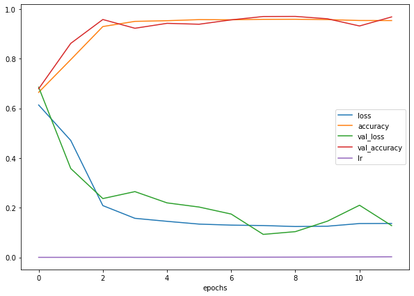

```python
pd.DataFrame(history_model_1.history).plot(figsize=(10,7), xlabel='epochs')
```

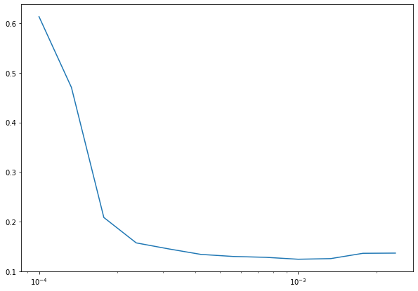

```python
# Plotting the learning rate versus the loss
lrs = 1e-4 * (10 ** (tf.range(12)/8))
plt.figure(figsize=(10, 7))
plt.semilogx(lrs, history_model_1.history['loss'])
```

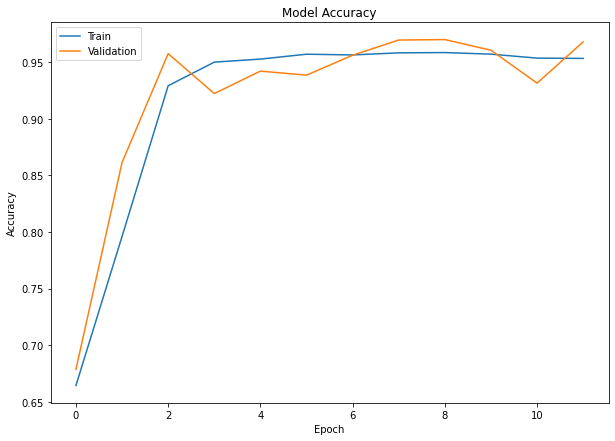

```python
plt.figure(figsize=(10, 7))
plt.plot(history_model_1.history['accuracy'])
plt.plot(history_model_1.history['val_accuracy'])
plt.title('Model Accuracy')
plt.ylabel('Accuracy')
plt.xlabel('Epoch')
plt.legend(['Train', 'Validation'], loc='upper left')
plt.show()
```

```python
pred = model_1.predict(test_images_n)
pred = tf.round(pred) # converting prediction probabilities to binary format

conf = confusion_matrix(test_labels, pred)
```

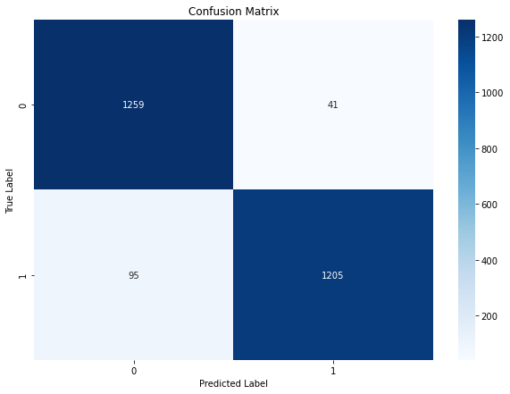

```python
plt.rcParams.update({'font.size': 10})
plt.figure(figsize=(10, 7))
import seaborn as sns
sns.heatmap(conf, annot=True, cmap='Blues', fmt='g')

plt.xlabel("Predicted Label")
plt.ylabel("True Label")
plt.title("Confusion Matrix")
```

```python
loss, accuracy = model_1.evaluate(test_images_n, test_labels)
print(f'Model loss on the test set: {loss}')
print(f'Model accuracy on the test set: {(accuracy*100): .2f}%')
```

```
Model loss on the test set: 0.16108182072639465
Model accuracy on the test set:  94.77%
```

```python
print(classification_report(test_labels, pred))
```

```
              precision    recall  f1-score   support

           0       0.93      0.97      0.95      1300
           1       0.97      0.93      0.95      1300

    accuracy                           0.95      2600
   macro avg       0.95      0.95      0.95      2600
weighted avg       0.95      0.95      0.95      2600
```

**Saving out our model and model history before we move to model 2**

```python
# Prepping our model before we save it out
from tensorflow.keras.models import Model
from tensorflow.python.keras.layers import deserialize, serialize
from tensorflow.python.keras.saving import saving_utils

def unpack(model, training_config, weights):
    restored_model = deserialize(model)

    if training_config is not None:
        restored_model.compile(**saving_utils.compile_args_from_training_config(
        training_config))

    restored_model.set_weights(weights)

    return restored_model

def make_keras_picklable():

    def __reduce__(self):
        model_metadata = saving_utils.model_metadata(self)
        training_config = model_metadata.get("training_config", None)
        model = serialize(self)
        weights = self.get_weights()
        return (unpack, (model, training_config, weights))

    cls = Model
    cls.__reduce__ = __reduce__

# Run the function
make_keras_picklable()
```

```python
# Saving out our model and model history
with open('model_1.pkl', 'wb') as f:
    pickle.dump(model_1, f)

with open('history_model_1.pkl', 'wb') as f:
    pickle.dump(history_model_1, f)
```

```python
# To load back the model and model history
# with open('model_1.pkl', 'rb') as f:
#     model_1 = pickle.load(f)

# with open('history_model_1.pkl', 'rb') as f:
#     history_model_1 = pickle.load(f)
```

## **Model 2 - Bayesian Optimization Parameters**

```python
# Clearing backend
from tensorflow.keras import backend
backend.clear_session()
```

```python
# Clearing memory
import gc
gc.collect()
del model_1
del history_model_1
```

```python
#Fixing the seed for random number generators
np.random.seed(42)
tf.random.set_seed(42)
```

```python
#Define the function
def cnn_model_2():
    model_2 = Sequential()

    #Adding our layers
    model_2.add(Conv2D(filters=128, kernel_size=(3, 3), padding="same", input_shape=(64, 64, 3)))
    model_2.add(LeakyReLU(0.1))
    model_2.add(Dropout(0.4))

    model_2.add(Conv2D(filters=160, kernel_size=(3, 3), padding='same'))
    model_2.add(LeakyReLU(0.1))
    model_2.add(MaxPool2D(pool_size=(2, 2)))
    model_2.add(Dropout(0.4))

    model_2.add(Conv2D(filters=32, kernel_size=(3, 3), padding='same'))
    model_2.add(LeakyReLU(0.1))
    model_2.add(MaxPool2D(pool_size=(2, 2)))
    model_2.add(Dropout(0.4))

    model_2.add(Conv2D(filters=32, kernel_size=(3, 3), padding='same'))
    model_2.add(LeakyReLU(0.1))
    model_2.add(MaxPool2D(pool_size=(2, 2)))
    model_2.add(Dropout(0.4))

    model_2.add(Flatten())

    model_2.add(Dense(128))
    model_2.add(LeakyReLU(0.1))
    model_2.add(Dropout(0.4))
    model_2.add(Dense(1, activation='sigmoid'))

    #declare adam optimizer with learning rate of 0.001
    adam = optimizers.Adam(learning_rate=0.001)

    #compile the model
    model_2.compile(
        loss = 'binary_crossentropy',
        optimizer = adam,
        metrics = ['accuracy'])

    return model_2
```

```python
#Build the model
model_2 = cnn_model_2()
```

```python
#Print the model summary
model_2.summary()
```

```
Model: "sequential"
_________________________________________________________________
Layer (type)                 Output Shape              Param #
=================================================================
conv2d (Conv2D)              (None, 64, 64, 128)       3584
_________________________________________________________________
leaky_re_lu (LeakyReLU)      (None, 64, 64, 128)       0
_________________________________________________________________
dropout (Dropout)            (None, 64, 64, 128)       0
_________________________________________________________________
conv2d_1 (Conv2D)            (None, 64, 64, 160)       184480
_________________________________________________________________
leaky_re_lu_1 (LeakyReLU)    (None, 64, 64, 160)       0
_________________________________________________________________
max_pooling2d (MaxPooling2D) (None, 32, 32, 160)       0
_________________________________________________________________
dropout_1 (Dropout)          (None, 32, 32, 160)       0
_________________________________________________________________
conv2d_2 (Conv2D)            (None, 32, 32, 32)        46112
_________________________________________________________________
leaky_re_lu_2 (LeakyReLU)    (None, 32, 32, 32)        0
_________________________________________________________________
max_pooling2d_1 (MaxPooling2 (None, 16, 16, 32)        0
_________________________________________________________________
dropout_2 (Dropout)          (None, 16, 16, 32)        0
_________________________________________________________________
conv2d_3 (Conv2D)            (None, 16, 16, 32)        9248
_________________________________________________________________
leaky_re_lu_3 (LeakyReLU)    (None, 16, 16, 32)        0
_________________________________________________________________
max_pooling2d_2 (MaxPooling2 (None, 8, 8, 32)          0
_________________________________________________________________
dropout_3 (Dropout)          (None, 8, 8, 32)          0
_________________________________________________________________
flatten (Flatten)            (None, 2048)              0
_________________________________________________________________
dense (Dense)                (None, 128)               262272
_________________________________________________________________
leaky_re_lu_4 (LeakyReLU)    (None, 128)               0
_________________________________________________________________
dropout_4 (Dropout)          (None, 128)               0
_________________________________________________________________
dense_1 (Dense)              (None, 1)                 129
=================================================================
Total params: 505,825
Trainable params: 505,825
Non-trainable params: 0
_________________________________________________________________
```

```python
# Fit the model
history_model_2 = model_2.fit(
            train_images_n,
            train_labels,
            epochs=8,
            validation_split=0.2,
            batch_size=32,
            verbose=2)
```

```
624/624 - 679s - loss: 0.4075 - accuracy: 0.7999 - val_loss: 0.2214 - val_accuracy: 0.9513
624/624 - 683s - loss: 0.1581 - accuracy: 0.9481 - val_loss: 0.1994 - val_accuracy: 0.9515
624/624 - 667s - loss: 0.1443 - accuracy: 0.9524 - val_loss: 0.1193 - val_accuracy: 0.9700
624/624 - 665s - loss: 0.1393 - accuracy: 0.9544 - val_loss: 0.1305 - val_accuracy: 0.9647
624/624 - 662s - loss: 0.1344 - accuracy: 0.9555 - val_loss: 0.1352 - val_accuracy: 0.9655
624/624 - 662s - loss: 0.1300 - accuracy: 0.9564 - val_loss: 0.1230 - val_accuracy: 0.9722
624/624 - 654s - loss: 0.1299 - accuracy: 0.9569 - val_loss: 0.1529 - val_accuracy: 0.9657
624/624 - 664s - loss: 0.1225 - accuracy: 0.9575 - val_loss: 0.1140 - val_accuracy: 0.9712
```

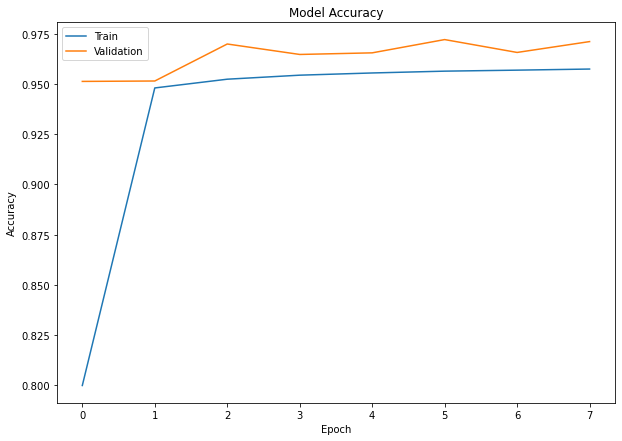

```python
plt.figure(figsize=(10, 7))
plt.plot(history_model_2.history['accuracy'])
plt.plot(history_model_2.history['val_accuracy'])
plt.title('Model Accuracy')
plt.ylabel('Accuracy')
plt.xlabel('Epoch')
plt.legend(['Train', 'Validation'], loc='upper left')
plt.show()
```

```python
pred = model_2.predict(test_images_n)
pred = tf.round(pred) # converting prediction probabilities to binary format

conf = confusion_matrix(test_labels, pred)
```

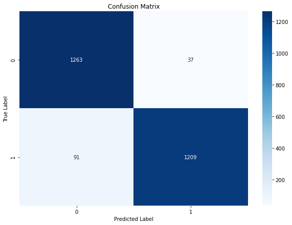

```python
import seaborn as sns
plt.figure(figsize=(10, 7))
sns.heatmap(conf, annot=True, cmap='Blues', fmt='g')
plt.xlabel("Predicted Label")
plt.ylabel("True Label")
plt.title("Confusion Matrix")
```

```python
loss, accuracy = model_2.evaluate(test_images_n, test_labels)
print(f'Model loss on the test set: {loss}')
print(f'Model accuracy on the test set: {(accuracy*100): .2f}%')
```

```
Model loss on the test set: 0.1612130105495453
Model accuracy on the test set:  95.08%
```

```python
print(classification_report(test_labels, pred))
```

```
              precision    recall  f1-score   support

           0       0.93      0.97      0.95      1300
           1       0.97      0.93      0.95      1300

    accuracy                           0.95      2600
   macro avg       0.95      0.95      0.95      2600
weighted avg       0.95      0.95      0.95      2600
```

**Observations**

- **Model 2** has **93% recall, 97% precision and 95% f1-score** on the test set. Same as model 1. Not surprising because both **Random Search** and **Bayesian Optimization** tuning methods came with very similar architecture. Althought **Random Search** did a little better, **Bayesian Optimization** seems to rely less on brute force. However, the **Random Search** model is a little quicker to train so I would learn towards the first model.

Let's see how a **transfer learning** model compares against these two.

**Saving out our model and model history before we move to model 3**

```python
# Run the function
make_keras_picklable()

# Saving out our model and model history
with open('model_2.pkl', 'wb') as f:
    pickle.dump(model_2, f)

with open('history_model_2.pkl', 'wb') as f:
    pickle.dump(history_model_2, f)
```

```python
# To load back the model and model history
with open('model_2.pkl', 'rb') as f:
    model_2 = pickle.load(f)

with open('history_model_2.pkl', 'rb') as f:
    history_model_2 = pickle.load(f)
```

## **Model 3 - Transfer Learning Model**

**Transfer learning** is a popular deep learning technique that **reuses a pre-trained model on a new problem**. **It can train deep neural networks with comparatively little data.** This is very useful in the data science field since most real-world problems typically do not have millions of labeled data points to train complex models.

Let's begin by clearing the backend and fixing the seed.

```python
# Clearing backend and memory
backend.clear_session()
gc.collect()
del model_2
del history_model_2
```

```python
#Fixing the seed for random number generators
np.random.seed(42)
tf.random.set_seed(42)
```

We will use VGG16 as the pre-trained model. You can read about it [here](https://www.tensorflow.org/api_docs/python/tf/keras/applications/vgg16/VGG16).

Also, we will use the **Functional Model API** to build the model this time because it allows explicitly connecting the output of one layer to the input of another layer. Each connection is specified. You can read about it [here](https://www.tensorflow.org/guide/keras/functional).

```python
#Importing necessary libraries
from tensorflow.keras import Model
from tensorflow.keras.applications.vgg16 import VGG16
```

Now, let's instantiate the VGG16 model.

- The **VGG16 model was originally trained on images of size 224 x 224**. The **TensorFlow application allows the minimum image size of 32x32** which fortunately is smaller than the image size of our dataset. We will change the size of the input image to **64x64**.
- By specifying the **argument include_top=False argument**, we load a **network that doesn't include the classification layers at the top** i.e. **we will use the VGG16 model only for feature extraction.**

```python
vgg_model = VGG16(weights='imagenet',
                       include_top=False,
                       input_shape=(64, 64, 3), pooling='max')
```

```
Downloading data from https://storage.googleapis.com/tensorflow/keras-applications/vgg16/vgg16_weights_tf_dim_ordering_tf_kernels_notop.h5
```

```python
vgg_model.summary()
```

```
Model: "vgg16"
_________________________________________________________________
Layer (type)                 Output Shape              Param #
=================================================================
input_1 (InputLayer)         [(None, 64, 64, 3)]       0
_________________________________________________________________
block1_conv1 (Conv2D)        (None, 64, 64, 64)        1792
_________________________________________________________________
block1_conv2 (Conv2D)        (None, 64, 64, 64)        36928
_________________________________________________________________
block1_pool (MaxPooling2D)   (None, 32, 32, 64)        0
_________________________________________________________________
block2_conv1 (Conv2D)        (None, 32, 32, 128)       73856
_________________________________________________________________
block2_conv2 (Conv2D)        (None, 32, 32, 128)       147584
_________________________________________________________________
block2_pool (MaxPooling2D)   (None, 16, 16, 128)       0
_________________________________________________________________
block3_conv1 (Conv2D)        (None, 16, 16, 256)       295168
_________________________________________________________________
block3_conv2 (Conv2D)        (None, 16, 16, 256)       590080
_________________________________________________________________
block3_conv3 (Conv2D)        (None, 16, 16, 256)       590080
_________________________________________________________________
block3_pool (MaxPooling2D)   (None, 8, 8, 256)         0
_________________________________________________________________
block4_conv1 (Conv2D)        (None, 8, 8, 512)         1180160
_________________________________________________________________
block4_conv2 (Conv2D)        (None, 8, 8, 512)         2359808
_________________________________________________________________
block4_conv3 (Conv2D)        (None, 8, 8, 512)         2359808
_________________________________________________________________
block4_pool (MaxPooling2D)   (None, 4, 4, 512)         0
_________________________________________________________________
block5_conv1 (Conv2D)        (None, 4, 4, 512)         2359808
_________________________________________________________________
block5_conv2 (Conv2D)        (None, 4, 4, 512)         2359808
_________________________________________________________________
block5_conv3 (Conv2D)        (None, 4, 4, 512)         2359808
_________________________________________________________________
block5_pool (MaxPooling2D)   (None, 2, 2, 512)         0
_________________________________________________________________
global_max_pooling2d (Global (None, 512)               0
=================================================================
Total params: 14,714,688
Trainable params: 14,714,688
Non-trainable params: 0
_________________________________________________________________
```

- The VGG16 model has **more than 14.7M trainable parameters.**
- Here, **we will not train any of the layers from the VGG16 model**. We will use the pre-trained weights and biases.
- Also, we can take any layer's output from the VGG16 model as the input of our new model. Here, **we will take the output of the 3rd block of the VGG16 model as the input of our new model.**

```python
transfer_layer = vgg_model.get_layer('block3_pool')
```

```python
vgg_model.trainable=False
```

Now, we will add classification layers to our model using Functional Model API

```python
# Add classification layers on top of it

x = Flatten()(transfer_layer.output) #Flatten the output from the 3rd block of the VGG16 model
x = Dense(32, activation = LeakyReLU(.1))(x)
x = Dropout(0.3)(x)

pred = Dense(1, activation='sigmoid')(x)

model_3 = Model(vgg_model.input, pred) #Initializing the model
```

```python
#Compiling the model
model_3.compile(loss='binary_crossentropy',
              optimizer = optimizers.Adam(learning_rate = 0.001),
              metrics=['accuracy'])
```

```python
#Print the model summary
model_3.summary()
```

```
Model: "model_2"
_________________________________________________________________
Layer (type)                 Output Shape              Param #
=================================================================
input_1 (InputLayer)         [(None, 64, 64, 3)]       0
_________________________________________________________________
block1_conv1 (Conv2D)        (None, 64, 64, 64)        1792
_________________________________________________________________
block1_conv2 (Conv2D)        (None, 64, 64, 64)        36928
_________________________________________________________________
block1_pool (MaxPooling2D)   (None, 32, 32, 64)        0
_________________________________________________________________
block2_conv1 (Conv2D)        (None, 32, 32, 128)       73856
_________________________________________________________________
block2_conv2 (Conv2D)        (None, 32, 32, 128)       147584
_________________________________________________________________
block2_pool (MaxPooling2D)   (None, 16, 16, 128)       0
_________________________________________________________________
block3_conv1 (Conv2D)        (None, 16, 16, 256)       295168
_________________________________________________________________
block3_conv2 (Conv2D)        (None, 16, 16, 256)       590080
_________________________________________________________________
block3_conv3 (Conv2D)        (None, 16, 16, 256)       590080
_________________________________________________________________
block3_pool (MaxPooling2D)   (None, 8, 8, 256)         0
_________________________________________________________________
flatten_2 (Flatten)          (None, 16384)             0
_________________________________________________________________
dense_4 (Dense)              (None, 32)                524320
_________________________________________________________________
dropout_2 (Dropout)          (None, 32)                0
_________________________________________________________________
dense_5 (Dense)              (None, 1)                 33
=================================================================
Total params: 2,259,841
Trainable params: 524,353
Non-trainable params: 1,735,488
_________________________________________________________________
```

```python
#Fitting the model
history_model_3 = model_3.fit(
            train_images_n,
            train_labels,
            epochs=8,
            validation_split=0.2,
            batch_size=32,
            verbose=2)
```

```
624/624 - 172s - loss: 5.1438 - accuracy: 0.8200 - val_loss: 2.1814 - val_accuracy: 0.8594
624/624 - 169s - loss: 1.7744 - accuracy: 0.8874 - val_loss: 4.2292 - val_accuracy: 0.6627
624/624 - 172s - loss: 0.9426 - accuracy: 0.9100 - val_loss: 1.4613 - val_accuracy: 0.8538
624/624 - 173s - loss: 0.4533 - accuracy: 0.9239 - val_loss: 0.5911 - val_accuracy: 0.8992
624/624 - 170s - loss: 0.2018 - accuracy: 0.9413 - val_loss: 1.1263 - val_accuracy: 0.6508
624/624 - 172s - loss: 0.1516 - accuracy: 0.9458 - val_loss: 0.3208 - val_accuracy: 0.9081
624/624 - 172s - loss: 0.1314 - accuracy: 0.9514 - val_loss: 0.5801 - val_accuracy: 0.8083
624/624 - 172s - loss: 0.1344 - accuracy: 0.9491 - val_loss: 0.4985 - val_accuracy: 0.8431
```

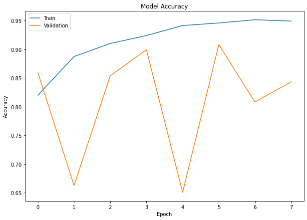

```python
plt.figure(figsize=(10, 7))
plt.plot(history_model_3.history['accuracy'])
plt.plot(history_model_3.history['val_accuracy'])
plt.title('Model Accuracy')
plt.ylabel('Accuracy')
plt.xlabel('Epoch')
plt.legend(['Train', 'Validation'], loc='upper left')
plt.show()
```

```python
pred = model_3.predict(test_images_n)
pred = tf.round(pred) # converting prediction probabilities to binary format

conf = confusion_matrix(test_labels, pred)
```

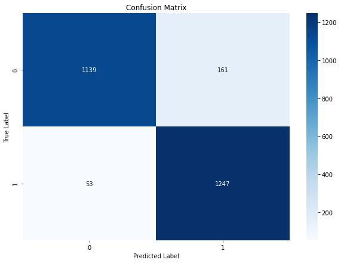

```python
import seaborn as sns
plt.figure(figsize=(10, 7))
sns.heatmap(conf, annot=True, cmap='Blues', fmt='g')
plt.xlabel("Predicted Label")
plt.ylabel("True Label")
plt.title("Confusion Matrix")
```

```python
loss, accuracy = model_3.evaluate(test_images_n, test_labels)
print(f'Model loss on the test set: {loss}')
print(f'Model accuracy on the test set: {(accuracy*100): .2f}%')
```

```
Model loss on the test set: 0.2482037991285324
Model accuracy on the test set:  91.77%
```

```python
print(classification_report(test_labels, pred))
```

```
              precision    recall  f1-score   support

           0       0.96      0.88      0.91      1300
           1       0.89      0.96      0.92      1300

    accuracy                           0.92      2600
   macro avg       0.92      0.92      0.92      2600
weighted avg       0.92      0.92      0.92      2600
```

```python
# Run the function
make_keras_picklable()

# Saving out our model and model history
with open('model_3.pkl', 'wb') as f:
    pickle.dump(model_3, f)

with open('history_model_3.pkl', 'wb') as f:
    pickle.dump(history_model_3, f)
```

**Observations**

- **Model 3** has **96% recall, 89% precision and 92% f1-score** on the test set. **Recall score** is an improvement over model 2, but the precision score dropped lower. The model is less likely to have false negatives than false positives.
- The validation scores are are not improving along with training scores which implies the model either is **overfitting** or **learning rate** needs to be adjusted.

Let's see if we can do a **Bayesian Hyperparameter Optimization on this model** and see if there's improvement in **model 4**.

## **Model 4 and Model 5 - Bayesian Optimization on Transfer Learning Model**

Let's see if we can optimize the some of the parameters to improve on the **Transfer learning** model.

```python
# Clearing backend and memory
backend.clear_session()
gc.collect()
del model_3
del history_model_3
```

```python
#Fixing the seed for random number generators
np.random.seed(42)
tf.random.set_seed(42)
```

```python
def build_tf_model(hp):  # random search passes this hyperparameter() object


    x = Flatten()(transfer_layer.output) #Flatten the output from the 3rd block of the VGG16 model
    x = Dense(hp.Int('input_units',
                     min_value=16,
                     max_value=160,
                     step=16),
              activation = LeakyReLU(.1))(x)

    x = Dropout(hp.Float('dropout',
                    min_value=0.0,
                    max_value=0.9,
                    step=0.1))(x)

    pred = Dense(1, activation='sigmoid')(x)

    model = Model(vgg_model.input, pred) #Initializing the model

    adam = optimizers.Adam(
        learning_rate=tf.Variable(0.001),
        beta_1=tf.Variable(0.9),
        beta_2=tf.Variable(0.999),
        epsilon=tf.Variable(1e-7))
    adam.iterations
    adam.decay = tf.Variable(0.0)

    model.compile(
        loss = 'binary_crossentropy',
        optimizer = adam,
        metrics = ['accuracy'])

    return model
```

```python
LOG_DIR = f"{int(time.time())}"

tuner_bo_tf = BayesianOptimization(
    build_tf_model,
    objective='val_accuracy',
    max_trials=1,  # how many model variations to test?
    executions_per_trial=1,  # how many trials per variation? (same model could perform differently)
    directory=LOG_DIR)

tuner_bo_tf.search(x=train_images_n,
             y=train_labels,
             verbose=2, # just slapping this here bc jupyter notebook. The console out was getting messy.
             epochs=2,
             batch_size=64,
             validation_data=(test_images_n, test_labels))

# best_model = tuner_hb.get_best_models(num_models=1)[0]
# best_model.evaluate(x_test_scaled, y_test)
```

```
Trial 1 Complete [00h 06m 29s]
val_accuracy: 0.9188461303710938

Best val_accuracy So Far: 0.9188461303710938
Total elapsed time: 00h 06m 29s
INFO:tensorflow:Oracle triggered exit
```

```python
tuner_bo_tf.get_best_hyperparameters()[0].values
```

```
{'input_units': 112, 'dropout': 0.0}
```

```python
tuner_bo_tf.get_best_models()[0].summary()
```

```
Model: "model"
_________________________________________________________________
Layer (type)                 Output Shape              Param #
=================================================================
input_1 (InputLayer)         [(None, 64, 64, 3)]       0
_________________________________________________________________
block1_conv1 (Conv2D)        (None, 64, 64, 64)        1792
_________________________________________________________________
block1_conv2 (Conv2D)        (None, 64, 64, 64)        36928
_________________________________________________________________
block1_pool (MaxPooling2D)   (None, 32, 32, 64)        0
_________________________________________________________________
block2_conv1 (Conv2D)        (None, 32, 32, 128)       73856
_________________________________________________________________
block2_conv2 (Conv2D)        (None, 32, 32, 128)       147584
_________________________________________________________________
block2_pool (MaxPooling2D)   (None, 16, 16, 128)       0
_________________________________________________________________
block3_conv1 (Conv2D)        (None, 16, 16, 256)       295168
_________________________________________________________________
block3_conv2 (Conv2D)        (None, 16, 16, 256)       590080
_________________________________________________________________
block3_conv3 (Conv2D)        (None, 16, 16, 256)       590080
_________________________________________________________________
block3_pool (MaxPooling2D)   (None, 8, 8, 256)         0
_________________________________________________________________
flatten (Flatten)            (None, 16384)             0
_________________________________________________________________
dense (Dense)                (None, 112)               1835120
_________________________________________________________________
dropout (Dropout)            (None, 112)               0
_________________________________________________________________
dense_1 (Dense)              (None, 1)                 113
=================================================================
Total params: 3,570,721
Trainable params: 1,835,233
Non-trainable params: 1,735,488
_________________________________________________________________
```

```python
# Add classification layers on top of it

x = Flatten()(transfer_layer.output) #Flatten the output from the 3rd block of the VGG16 model
x = Dense(112, activation = LeakyReLU(.1))(x)
# x = Dropout(0.3)(x)

pred = Dense(1, activation='sigmoid')(x)

model_4 = Model(vgg_model.input, pred) #Initializing the model
```

```python
#Compiling the model
model_4.compile(loss='binary_crossentropy',
              optimizer = optimizers.Adam(),
              metrics=['accuracy'])
```

```python
# Let's test out different learning rate for each epoch to discover what's the best learning rate
lr_scheduler = tf.keras.callbacks.LearningRateScheduler(lambda epoch: 1e-4 * 10**(epoch/8))
```

```python
# Fit the model
history_model_4 = model_4.fit(
            train_images_n,
            train_labels,
            epochs=12,
            validation_split=0.2,
            batch_size=64,
            verbose=2,
            shuffle=True,
            callbacks=[lr_scheduler])
```

```
312/312 - 176s - loss: 0.8820 - accuracy: 0.8671 - val_loss: 0.3943 - val_accuracy: 0.8862
312/312 - 171s - loss: 0.3084 - accuracy: 0.9129 - val_loss: 0.7124 - val_accuracy: 0.8379
312/312 - 170s - loss: 0.2620 - accuracy: 0.9265 - val_loss: 3.7177 - val_accuracy: 0.2113
312/312 - 168s - loss: 0.2786 - accuracy: 0.9272 - val_loss: 0.3223 - val_accuracy: 0.9345
312/312 - 171s - loss: 0.3081 - accuracy: 0.9287 - val_loss: 1.6589 - val_accuracy: 0.6607
312/312 - 170s - loss: 0.2100 - accuracy: 0.9457 - val_loss: 0.6598 - val_accuracy: 0.8714
312/312 - 173s - loss: 0.2952 - accuracy: 0.9331 - val_loss: 1.2998 - val_accuracy: 0.8311
312/312 - 175s - loss: 0.3471 - accuracy: 0.9368 - val_loss: 0.4229 - val_accuracy: 0.9395
312/312 - 175s - loss: 0.3234 - accuracy: 0.9390 - val_loss: 1.0815 - val_accuracy: 0.8281
312/312 - 175s - loss: 0.3168 - accuracy: 0.9362 - val_loss: 1.9529 - val_accuracy: 0.6528
312/312 - 176s - loss: 0.3089 - accuracy: 0.9303 - val_loss: 0.4042 - val_accuracy: 0.9301
312/312 - 172s - loss: 0.2825 - accuracy: 0.9330 - val_loss: 0.4785 - val_accuracy: 0.8910
```

```python
pd.DataFrame(history_model_4.history)
```

|  | loss | accuracy | val_loss | val_accuracy | lr |
| --- | --- | --- | --- | --- | --- |
| 0 | 0.882008 | 0.867124 | 0.394314 | 0.886218 | 0.000100 |
| 1 | 0.308392 | 0.912902 | 0.712375 | 0.837941 | 0.000133 |
| 2 | 0.262040 | 0.926475 | 3.717664 | 0.211338 | 0.000178 |
| 3 | 0.278634 | 0.927176 | 0.322287 | 0.934495 | 0.000237 |
| 4 | 0.308082 | 0.928729 | 1.658879 | 0.660657 | 0.000316 |
| 5 | 0.210008 | 0.945708 | 0.659849 | 0.871394 | 0.000422 |
| 6 | 0.295241 | 0.933136 | 1.299849 | 0.831130 | 0.000562 |
| 7 | 0.347086 | 0.936843 | 0.422948 | 0.939503 | 0.000750 |
| 8 | 0.323374 | 0.939046 | 1.081469 | 0.828125 | 0.001000 |
| 9 | 0.316762 | 0.936191 | 1.952932 | 0.652845 | 0.001334 |
| 10 | 0.308893 | 0.930332 | 0.404164 | 0.930088 | 0.001778 |
| 11 | 0.282505 | 0.933036 | 0.478475 | 0.891026 | 0.002371 |

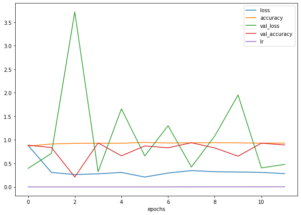

```python
pd.DataFrame(history_model_4.history).plot(figsize=(10,7), xlabel='epochs')
```

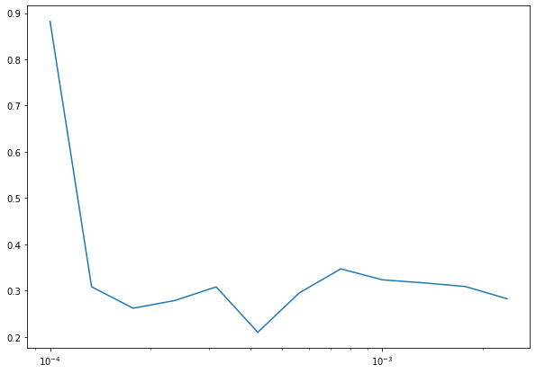

```python
# Plotting the learning rate versus the loss
lrs = 1e-4 * (10 ** (tf.range(12)/8))
plt.figure(figsize=(10, 7))
plt.semilogx(lrs, history_model_4.history['loss'])
```

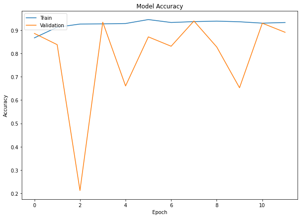

```python
plt.figure(figsize=(10, 7))
plt.plot(history_model_4.history['accuracy'])
plt.plot(history_model_4.history['val_accuracy'])
plt.title('Model Accuracy')
plt.ylabel('Accuracy')
plt.xlabel('Epoch')
plt.legend(['Train', 'Validation'], loc='upper left')
plt.show()
```

```python
pred = model_4.predict(test_images_n)
pred = tf.round(pred) # converting prediction probabilities to binary format

conf = confusion_matrix(test_labels, pred)
```

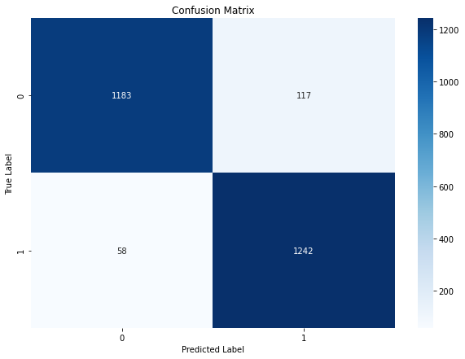

```python
plt.figure(figsize=(10, 7))
import seaborn as sns
sns.heatmap(conf, annot=True, cmap='Blues', fmt='g')
plt.xlabel("Predicted Label")
plt.ylabel("True Label")
plt.title("Confusion Matrix")
```

```python
loss, accuracy = model_4.evaluate(test_images_n, test_labels)
print(f'Model loss on the test set: {loss}')
print(f'Model accuracy on the test set: {(accuracy*100): .2f}%')
```

```
Model loss on the test set: 0.2784669101238251
Model accuracy on the test set:  93.27%
```

```python
print(classification_report(test_labels, pred))
```

```
              precision    recall  f1-score   support

           0       0.95      0.91      0.93      1300
           1       0.91      0.96      0.93      1300

    accuracy                           0.93      2600
   macro avg       0.93      0.93      0.93      2600
weighted avg       0.93      0.93      0.93      2600
```

**Observations**

- **Model 4** has **96% recall, 91% precision and 93% f1-score** on the test set. The score **improved about 2%** in precision score from the previous model.
- We have some guidance for parameter optimization from the Bayesian Hyperparameter Optimization. We will change our Dense layer to 112 nodes. And it looks like the learning rate is about .0005

Let's see if we apply the Bayesian Hyperparameter Optimization to model 5.

## **Model 5 - The Optimzed Transfer Learning Model**

```python
# Add classification layers on top of it

x = Flatten()(transfer_layer.output) #Flatten the output from the 3rd block of the VGG16 model
x = Dense(112, activation = LeakyReLU(.1))(x)
x = Dropout(0.2)(x)

pred = Dense(1, activation='sigmoid')(x)

model_5 = Model(vgg_model.input, pred) #Initializing the model
```

```python
#Compiling the model
model_5.compile(loss='binary_crossentropy',
              optimizer = optimizers.Adam(learning_rate = 0.0005),
              metrics=['accuracy'])
```

```python
#Print the model summary
model_5.summary()
```

```
Model: "model_2"
_________________________________________________________________
Layer (type)                 Output Shape              Param #
=================================================================
input_1 (InputLayer)         [(None, 64, 64, 3)]       0
_________________________________________________________________
block1_conv1 (Conv2D)        (None, 64, 64, 64)        1792
_________________________________________________________________
block1_conv2 (Conv2D)        (None, 64, 64, 64)        36928
_________________________________________________________________
block1_pool (MaxPooling2D)   (None, 32, 32, 64)        0
_________________________________________________________________
block2_conv1 (Conv2D)        (None, 32, 32, 128)       73856
_________________________________________________________________
block2_conv2 (Conv2D)        (None, 32, 32, 128)       147584
_________________________________________________________________
block2_pool (MaxPooling2D)   (None, 16, 16, 128)       0
_________________________________________________________________
block3_conv1 (Conv2D)        (None, 16, 16, 256)       295168
_________________________________________________________________
block3_conv2 (Conv2D)        (None, 16, 16, 256)       590080
_________________________________________________________________
block3_conv3 (Conv2D)        (None, 16, 16, 256)       590080
_________________________________________________________________
block3_pool (MaxPooling2D)   (None, 8, 8, 256)         0
_________________________________________________________________
flatten_2 (Flatten)          (None, 16384)             0
_________________________________________________________________
dense_4 (Dense)              (None, 112)               1835120
_________________________________________________________________
dropout_1 (Dropout)          (None, 112)               0
_________________________________________________________________
dense_5 (Dense)              (None, 1)                 113
=================================================================
Total params: 3,570,721
Trainable params: 1,835,233
Non-trainable params: 1,735,488
_________________________________________________________________
```

```python
#Fitting the model
history_model_5 = model_5.fit(
            train_images_n,
            train_labels,
            epochs=10,
            validation_split=0.2,
            batch_size=32,
            verbose=2)
```

```
624/624 - 179s - loss: 2.3957 - accuracy: 0.8510 - val_loss: 1.9762 - val_accuracy: 0.8628
624/624 - 178s - loss: 1.0294 - accuracy: 0.9019 - val_loss: 6.5051 - val_accuracy: 0.6082
624/624 - 176s - loss: 0.9628 - accuracy: 0.9125 - val_loss: 4.6442 - val_accuracy: 0.6014
624/624 - 176s - loss: 0.7542 - accuracy: 0.9194 - val_loss: 2.1513 - val_accuracy: 0.8037
624/624 - 175s - loss: 0.5044 - accuracy: 0.9344 - val_loss: 3.7209 - val_accuracy: 0.6130
624/624 - 173s - loss: 0.3935 - accuracy: 0.9349 - val_loss: 0.4993 - val_accuracy: 0.9227
624/624 - 170s - loss: 0.2735 - accuracy: 0.9424 - val_loss: 0.8082 - val_accuracy: 0.8622
624/624 - 172s - loss: 0.1978 - accuracy: 0.9463 - val_loss: 0.4328 - val_accuracy: 0.9038
624/624 - 166s - loss: 0.1390 - accuracy: 0.9533 - val_loss: 0.9036 - val_accuracy: 0.7524
624/624 - 170s - loss: 0.1285 - accuracy: 0.9530 - val_loss: 0.5086 - val_accuracy: 0.8576
```

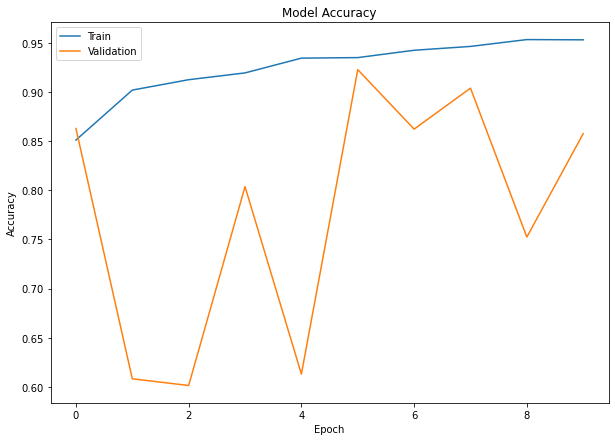

```python
plt.figure(figsize=(10, 7))
plt.plot(history_model_5.history['accuracy'])
plt.plot(history_model_5.history['val_accuracy'])
plt.title('Model Accuracy')
plt.ylabel('Accuracy')
plt.xlabel('Epoch')
plt.legend(['Train', 'Validation'], loc='upper left')
plt.show()
```

```python
pred = model_5.predict(test_images_n)
pred = tf.round(pred) # converting prediction probabilities to binary format

conf = confusion_matrix(test_labels, pred)
```

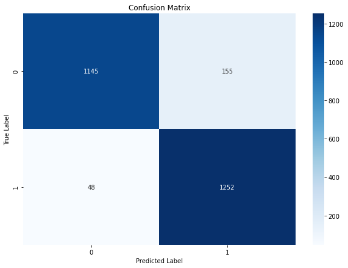

```python
import seaborn as sns
plt.figure(figsize=(10, 7))
sns.heatmap(conf, annot=True, cmap='Blues', fmt='g')
plt.xlabel("Predicted Label")
plt.ylabel("True Label")
plt.title("Confusion Matrix")
```

```python
loss, accuracy = model_5.evaluate(test_images_n, test_labels)
print(f'Model loss on the test set: {loss}')
print(f'Model accuracy on the test set: {(accuracy*100): .2f}%')
```

```
Model loss on the test set: 0.26750826835632324
Model accuracy on the test set:  92.19%
```

```python
print(classification_report(test_labels, pred))
```

```
              precision    recall  f1-score   support

           0       0.96      0.88      0.92      1300
           1       0.89      0.96      0.93      1300

    accuracy                           0.92      2600
   macro avg       0.92      0.92      0.92      2600
weighted avg       0.92      0.92      0.92      2600
```

**Observations**

- **Model 5** has **96% recall, 89% precision and 93% f1-score** on the test set. The precision score **dropped about 2%** in precision score from the previous model. This may be because we added a 20% **dropout layer** to see if it will avoid overfitting.
- However, the **validation scores are not tracking with training scores** as well, the model will need further work to be better. There appears to be some **overfitting**.

## Model Choice - Bayesian Optimized Model

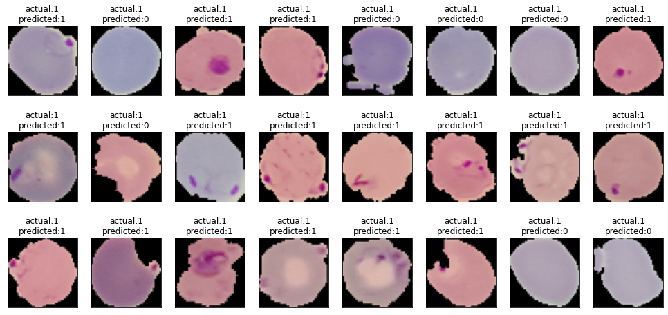

```python
seed(42)

fig, axes = plt.subplots(ncols=8, nrows=3, sharex=False,
    sharey=True, figsize=(17, 8))

for i in range(3):
    for j in range(8):
        index = sample(sequence, 24) # select a subset without replacement
        k = 0
        axes[i,j].set_title('actual:' + str(train_labels[index[k]]) + '\n'
                            + 'predicted:' + str(test_labels[index[k]]))
        axes[i,j].imshow(test_images_n[index[k]])
        axes[i,j].get_xaxis().set_visible(False)
        axes[i,j].get_yaxis().set_visible(False)
        k += 1

plt.show()
```

## **Problem and Solution Summary**

- In **previous milestone** we were able to build a pretty robust convolutional neural network to effectively identify malaria infected cells with a **89% recall, 98% precision and 93% f1-score** on the test set.
- In this notebook we **finalize** looked at some automated **parameter tuning** methods and also **transfer learning** and we saw slight improvement in our scores.
- Hyperparameter tuning is an effective method to find the best model architecture for machine learning problems and should be done early in the model building process.
- **Transfer Learning** can also be an effective method to use pretrained models on new problems, however, it requires some **adjustments** as well. There may also be issues of **overfitting** to resolve - this seems to be true in our case.

## **Solution**

- As noted above, **The Bayesian Optimized Model (2)** presents a robust and efficient model with a high accuracy rate with a **93% recall, 97% precision and 95% f1-score** on the test set.
- The **greater improvement** in the recall score means we will get less false negative.
- The model could, of course, continue to improve with more tuning but, at the current rate **it can be deployed**.

## **Recommendations for Implementation**

- The model requires images to be taken in a color format that can be converted to 64x64 image.
- It is recommended that a physician or trained health professional examine the scan following detection of malaria infection by the model to confirm accuracy of diagnosis.
- The model should be periodically retrained with new data to maintain accuracy.